# R0

Tyler Richards

# Basic Operations and Functions in R

## Why Learn R?

R is a data science specific langauge with a huge community of dedicated and helpful users in every field imaginable. Not only do Google, Microsoft, Uber, TechCrunch, P&G, the New York Times, and Bank of America use R, but also the best academic institutions in the world in every deparment from journalism to finance to political science and biology.

The goal of this workshop, and the next 2 R workshops, is to get you all from ‘man I have no idea how to do that’ to ‘yeah I think I could figure out how to do this.’

Before we get to all that, we need to set a good foundation for how R works.

We’ll begin by covering data types and classes, and then look into how to create vectors and dataframes, and after that we’ll work on how to manipulate your data by filtering and indexing.

## What is R?

R is an open source programming language and software environment for statistical computing and graphics.

R vs RStudio R is the langauge while RStudio is the integrated development environment(IDE) analagous to Eclipse for python.

Overview of RStudio

- console
- Scripts
- environment
- files, plots, packages

Arguments for an R function come in an order that you must implicitley accept or explicitly define.

R is keeps all your information in objects.

## Common data/object types

```r
#Numeric
x <- 4.8
print(class(x))
```

```
## [1] "numeric"
```

```r
#Integer
y <- as.integer(x)
print(y)
```

```
## [1] 4
```

```r
#Character
z <- "dog"
print(class(z))
```

```
## [1] "character"
```

```r
#Logical (also called Boolean)
a <- TRUE
print(class(a))
```

```
## [1] "logical"
```

```r
#factor
heat_setting <- factor(c("Low", "Medium", "High"))
print(class(heat_setting))
```

```
## [1] "factor"
```

## Data Structure Types

Major examples include Vectors, Matrices, Arrays, Data Frames, and Lists

### Vectors

```r
#Numerical vector
a<-c(1,2,3,4,5,6,7)
print(a)
```

```
## [1] 1 2 3 4 5 6 7
```

```r
#character vector
b<-c("one","two","three")
print(b)
```

```
## [1] "one"   "two"   "three"
```

```r
#Logical vector
c<-c(TRUE,FALSE,FALSE,TRUE)
print(c)
```

```
## [1]  TRUE FALSE FALSE  TRUE
```

```r
#Subsetting vectors
a
```

```
## [1] 1 2 3 4 5 6 7
```

```r
a[1]
```

```
## [1] 1
```

```r
a[2:5]
```

```
## [1] 2 3 4 5
```

```r
a[-1]
```

```
## [1] 2 3 4 5 6 7
```

```r
a[-(1:3)]
```

```
## [1] 4 5 6 7
```

```r
a[-length(a)]
```

```
## [1] 1 2 3 4 5 6
```

### Date Frames

```r
#first create vectors
studentID <- c(1, 2, 3, 4)
age <- c(25, 19, 22, 21)
university <- c("UF", "FSU", "UF", "UGA")
hired <- c(TRUE, FALSE, TRUE, FALSE)

#then combine them into a dataframe!
studentdata <- data.frame(studentID, age, university, hired)
studentdata
```

```
##   studentID age university hired
## 1         1  25         UF  TRUE
## 2         2  19        FSU FALSE
## 3         3  22         UF  TRUE
## 4         4  21        UGA FALSE
```

```r
#Subsetting dataframes
studentdata[1,3]
```

```
## [1] UF
## Levels: FSU UF UGA
```

```r
studentdata[1,"hired"]
```

```
## [1] TRUE
```

```r
studentdata$age
```

```
## [1] 25 19 22 21
```

### Logicals

Logicals in R deal with `TRUE` and `FALSE` operations. These are also known as boolean operaters in many programming languages.

We obtain logical expressions by comparing values using logical operaters.

Logical operaters in R include the following:

- equal: `==`
- not equal: `!=`
- greater/less than: `> <`
- greater/less than or equal: `>= <=`

Examples:

```r
3<4
```

```
## [1] TRUE
```

```r
4>3*2
```

```
## [1] FALSE
```

```r
3==3*1
```

```
## [1] TRUE
```

```r
x<-c(-1,0,1,2,3,4)
xx<-c(-1:4)

x==xx
```

```
## [1] TRUE TRUE TRUE TRUE TRUE TRUE
```

```r
x<=3
```

```
## [1]  TRUE  TRUE  TRUE  TRUE  TRUE FALSE
```

```r
y<-c(2,2,2,2,2,2)
yy<-rep(2,6)

y!=yy
```

```
## [1] FALSE FALSE FALSE FALSE FALSE FALSE
```

```r
x==y
```

```
## [1] FALSE FALSE FALSE  TRUE FALSE FALSE
```

```r
##Comparing logicals
(x<pi)==(x<=3)
```

```
## [1] TRUE TRUE TRUE TRUE TRUE TRUE
```

Here we will introduce some common checks using logicals

```r
x<pi
```

```
## [1]  TRUE  TRUE  TRUE  TRUE  TRUE FALSE
```

```r
##are any values in x less than pi
sum(x<pi) >  0
```

```
## [1] TRUE
```

```r
##are all values greater than -1
sum(x< -1) > 0
```

```
## [1] FALSE
```

```r
#picking specific values by subsetting with logical vectors
x[x<pi]
```

```
## [1] -1  0  1  2  3
```

We can also directly manipulate logicals using the following operaters:

- `!` ==> negation
- `&` or `&&` ==> intersection
- `|` or `||` ==> union

The shorter form performs elementwise comparisons in much the same way as arithmetic operators. The longer form evaluates left to right examining only the first element of each vector.

```r
u = TRUE; v = FALSE
u & v          # u AND v
```

```
## [1] FALSE
```

```r
u | v          # u OR v
```

```
## [1] TRUE
```

```r
!u             # negation of u
```

```
## [1] FALSE
```

## Basic Functions for working with data

We will use the “mtcars” dataset to apply some of these ideas. This dataset is preinstalled with R to be used pretty much for the purpose of trying things out.

The **head()** function shows you the top six rows while **tail()** shows the last six rows. Another useful function is the **str()** which gives a description of the structure of the data.

```r
class(mtcars)
```

```
## [1] "data.frame"
```

```r
str(mtcars)
```

```
## 'data.frame':    32 obs. of  11 variables:
##  $ mpg : num  21 21 22.8 21.4 18.7 18.1 14.3 24.4 22.8 19.2 ...
##  $ cyl : num  6 6 4 6 8 6 8 4 4 6 ...
##  $ disp: num  160 160 108 258 360 ...
##  $ hp  : num  110 110 93 110 175 105 245 62 95 123 ...
##  $ drat: num  3.9 3.9 3.85 3.08 3.15 2.76 3.21 3.69 3.92 3.92 ...
##  $ wt  : num  2.62 2.88 2.32 3.21 3.44 ...
##  $ qsec: num  16.5 17 18.6 19.4 17 ...
##  $ vs  : num  0 0 1 1 0 1 0 1 1 1 ...
##  $ am  : num  1 1 1 0 0 0 0 0 0 0 ...
##  $ gear: num  4 4 4 3 3 3 3 4 4 4 ...
##  $ carb: num  4 4 1 1 2 1 4 2 2 4 ...
```

```r
head(mtcars)
```

```
##                    mpg cyl disp  hp drat    wt  qsec vs am gear carb
## Mazda RX4         21.0   6  160 110 3.90 2.620 16.46  0  1    4    4
## Mazda RX4 Wag     21.0   6  160 110 3.90 2.875 17.02  0  1    4    4
## Datsun 710        22.8   4  108  93 3.85 2.320 18.61  1  1    4    1
## Hornet 4 Drive    21.4   6  258 110 3.08 3.215 19.44  1  0    3    1
## Hornet Sportabout 18.7   8  360 175 3.15 3.440 17.02  0  0    3    2
## Valiant           18.1   6  225 105 2.76 3.460 20.22  1  0    3    1
```

```r
tail(mtcars)
```

```
##                 mpg cyl  disp  hp drat    wt qsec vs am gear carb
## Porsche 914-2  26.0   4 120.3  91 4.43 2.140 16.7  0  1    5    2
## Lotus Europa   30.4   4  95.1 113 3.77 1.513 16.9  1  1    5    2
## Ford Pantera L 15.8   8 351.0 264 4.22 3.170 14.5  0  1    5    4
## Ferrari Dino   19.7   6 145.0 175 3.62 2.770 15.5  0  1    5    6
## Maserati Bora  15.0   8 301.0 335 3.54 3.570 14.6  0  1    5    8
## Volvo 142E     21.4   4 121.0 109 4.11 2.780 18.6  1  1    4    2
```

## Visualizing Data

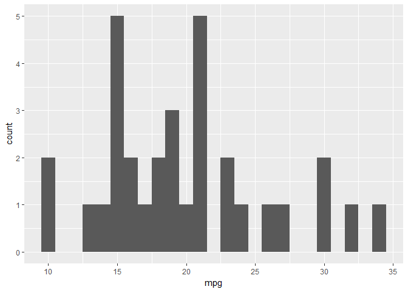

```r
library(ggplot2)
hist.ggplot <- ggplot(mtcars, aes(x=mpg)) + geom_histogram(binwidth=1)
hist.ggplot
```

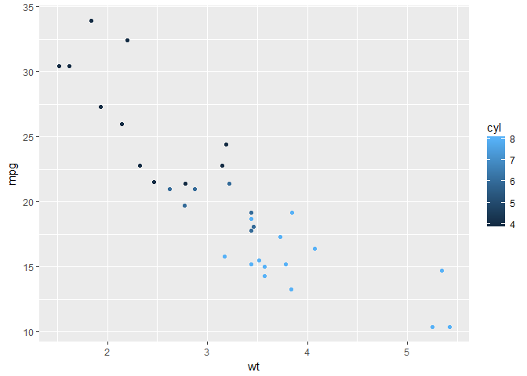

```r
scatter.ggplot <- ggplot(mtcars, aes(x=wt, y=mpg, colour=cyl)) + geom_point()
scatter.ggplot
```

```r
#we also have another dataset called mpg, let's check it out
summary(mpg)
```

```
##  manufacturer          model               displ            year
##  Length:234         Length:234         Min.   :1.600   Min.   :1999
##  Class :character   Class :character   1st Qu.:2.400   1st Qu.:1999
##  Mode  :character   Mode  :character   Median :3.300   Median :2004
##                                        Mean   :3.472   Mean   :2004
##                                        3rd Qu.:4.600   3rd Qu.:2008
##                                        Max.   :7.000   Max.   :2008
##       cyl           trans               drv                 cty
##  Min.   :4.000   Length:234         Length:234         Min.   : 9.00
##  1st Qu.:4.000   Class :character   Class :character   1st Qu.:14.00
##  Median :6.000   Mode  :character   Mode  :character   Median :17.00
##  Mean   :5.889                                         Mean   :16.86
##  3rd Qu.:8.000                                         3rd Qu.:19.00
##  Max.   :8.000                                         Max.   :35.00
##       hwy             fl               class
##  Min.   :12.00   Length:234         Length:234
##  1st Qu.:18.00   Class :character   Class :character
##  Median :24.00   Mode  :character   Mode  :character
##  Mean   :23.44
##  3rd Qu.:27.00
##  Max.   :44.00
```

```r
str(mpg)
```

```
## Classes 'tbl_df', 'tbl' and 'data.frame':    234 obs. of  11 variables:
##  $ manufacturer: chr  "audi" "audi" "audi" "audi" ...
##  $ model       : chr  "a4" "a4" "a4" "a4" ...
##  $ displ       : num  1.8 1.8 2 2 2.8 2.8 3.1 1.8 1.8 2 ...
##  $ year        : int  1999 1999 2008 2008 1999 1999 2008 1999 1999 2008 ...
##  $ cyl         : int  4 4 4 4 6 6 6 4 4 4 ...
##  $ trans       : chr  "auto(l5)" "manual(m5)" "manual(m6)" "auto(av)" ...
##  $ drv         : chr  "f" "f" "f" "f" ...
##  $ cty         : int  18 21 20 21 16 18 18 18 16 20 ...
##  $ hwy         : int  29 29 31 30 26 26 27 26 25 28 ...
##  $ fl          : chr  "p" "p" "p" "p" ...
##  $ class       : chr  "compact" "compact" "compact" "compact" ...
```

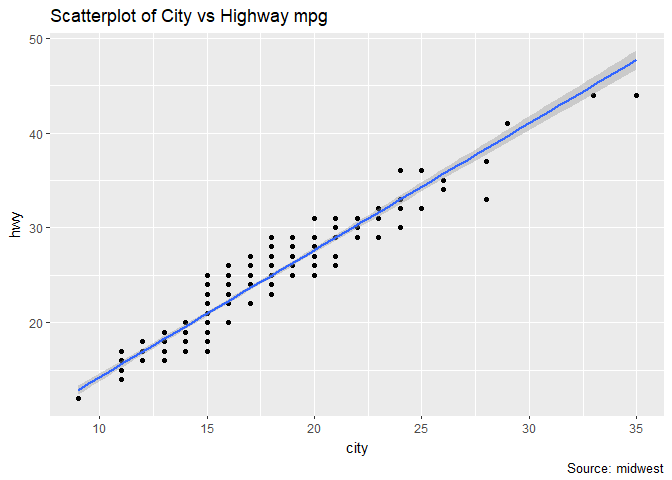

```r
ggplot(mpg, aes(cty ,hwy)) + geom_point() + geom_smooth(method = "lm") + labs(y = "hwy", x = "city", title = "Scatterplot of City vs Highway mpg", caption = "Source: midwest")
```

There are great packages for econometrics, check one out

```r
library(AER)
str(Affairs)
```

[output not shown]

```r
data("Affairs")
hist.ggplot <- ggplot(Affairs, aes(x=affairs)) + geom_histogram(binwidth=1)
hist.ggplot
```

[output not shown]